# assessment 4

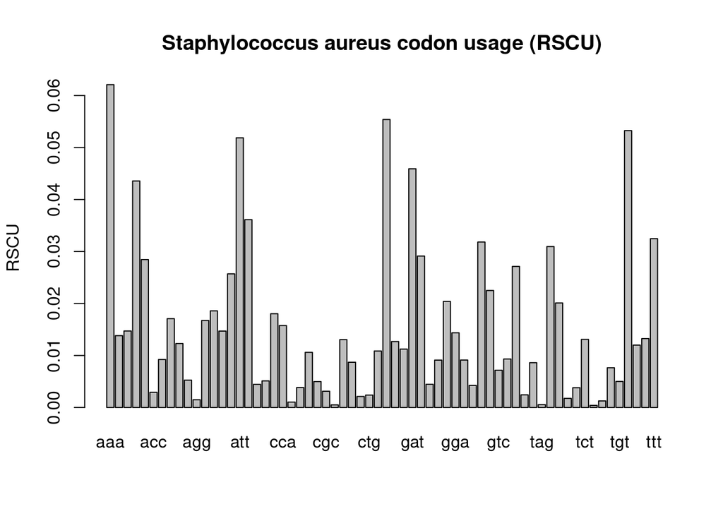

```r
barplot(rscu_S$freq, names.arg = rscu_S$codon,
        main = "Staphylococcus aureus codon usage (RSCU)",
        ylab = "RSCU")
```

#The RSCU plots depicts that codon usage is not random. Each organism has a distinct pattern of preferred codons determined by genomic base composition. e.coli prefers G/C ending codons and S.aureus favours A/T ending codons.

```r
# Q6-Flatten proteins into single character vectors
prots_ecoli <- unlist(lapply(cds_ecoli, translate))
prots_S   <- unlist(lapply(cds_S,   translate))
```

```r
# Define amino acid alphabet (drop stop codons '*')
aa <- unique(prots_ecoli)
aa <- aa[aa != "*"]
```

```r
#Count 3-mers
k3_ecoli <- count(prots_ecoli, wordsize=3, alphabet=aa)
k3_S   <- count(prots_S,   wordsize=3, alphabet=aa)
```

```r
# Top 10 over- and under-represented 3-mers in staphylococcus
top_over_S3  <- head(sort(k3_S, decreasing=TRUE), 10)
top_under_S3 <- head(sort(k3_S, decreasing=FALSE),10)

# Print for report
print(top_over_S3)
```

```
##
## SDS LLL LLI LKE ILL DSD LII EKL IIG LLK
## 699 661 626 620 614 589 561 557 555 551
```

```r
print(top_under_S3)
```

```
##
## CAW CCC CCR CCW CHW CKC CRC CWH CWR CWS
##   0   0   0   0   0   0   0   0   0   0
```

#The proteome’s preferred amino acid combinations are shown by the high frequency of the top 10 over-represented 3-mers (such as SDS, LLL, and LLI) in S. aureus proteins. The under-represented 3-mers, such as CAW, CCC, and CCR, on the other hand, are completely absent, suggesting that they are uncommon or avoided sequences. These patterns show biases in the composition of protein sequences that might affect the structure and function of proteins.

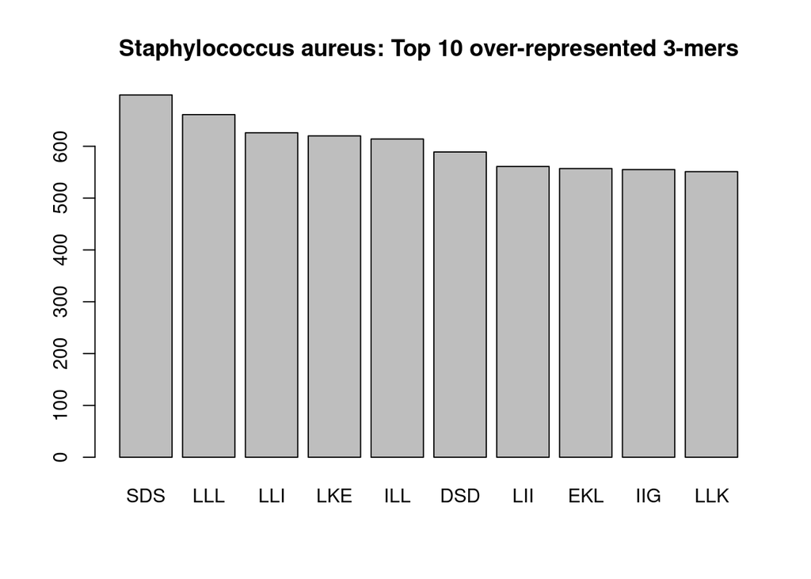

```r
#Plot top 10 over-represented 3-mers for Staphylococcus aureus
barplot(as.numeric(top_over_S3),
        names.arg = names(top_over_S3),
        main = "Staphylococcus aureus: Top 10 over-represented 3-mers")
```

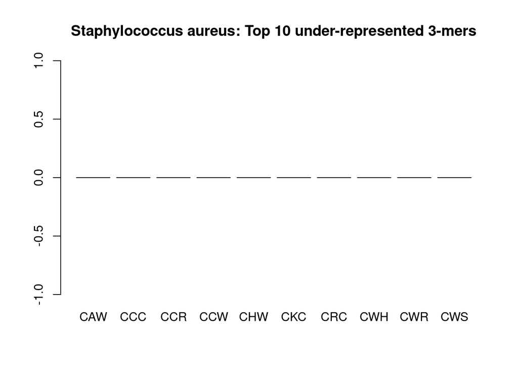

```r
# Plot top 10 under-represented 3-mers for Staphylococcus aureus
barplot(as.numeric(top_under_S3),
        names.arg = names(top_under_S3),
        main = "Staphylococcus aureus: Top 10 under-represented 3-mers")
```

```r
# Compare with E. coli counts for those same k-mers
k3_ecoli[names(top_over_S3)]
```

```
##
##  SDS  LLL  LLI  LKE  ILL  DSD  LII  EKL  IIG  LLK
##  217 1594  820  474  780  153  462  664  473  682
```

```r
k3_ecoli[names(top_under_S3)]
```

```
##
## CAW CCC CCR CCW CHW CKC CRC CWH CWR CWS
##  19   9  16   6   3   4   5  10  11  18
```

# The sequences most over-represented in S. aureus (e.g., LLL, LLI) are also found at high abundance in E. coli. This suggests these motifs are common and generally favored in bacterial proteins.The sequences most under-represented in S. aureus (e.g, CAW, CCC) are extremely rare in E. coli, indicating a shared avoidance of these specific, low-frequency amino acid combinations across both species.

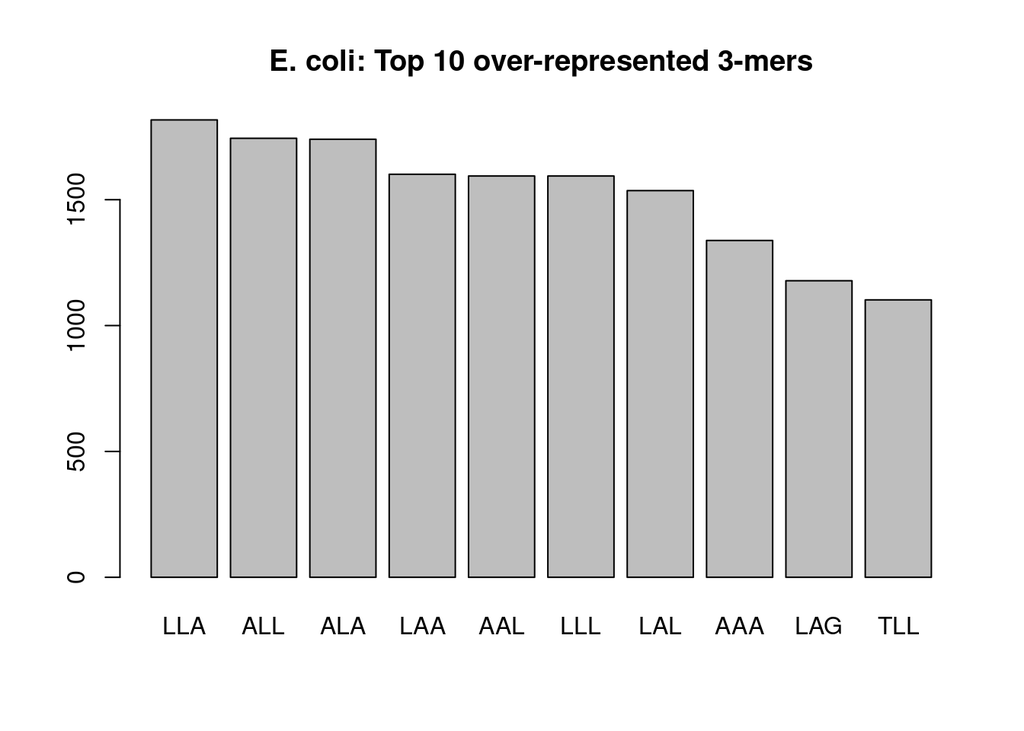

```r
# Plot top 10 over-represented 3-mers for E. coli
top_over_E3  <- head(sort(k3_ecoli, decreasing = TRUE), 10)
top_under_E3 <- head(sort(k3_ecoli, decreasing = FALSE), 10)

barplot(as.numeric(top_over_E3),
        names.arg = names(top_over_E3),
        main = "E. coli: Top 10 over-represented 3-mers")
```

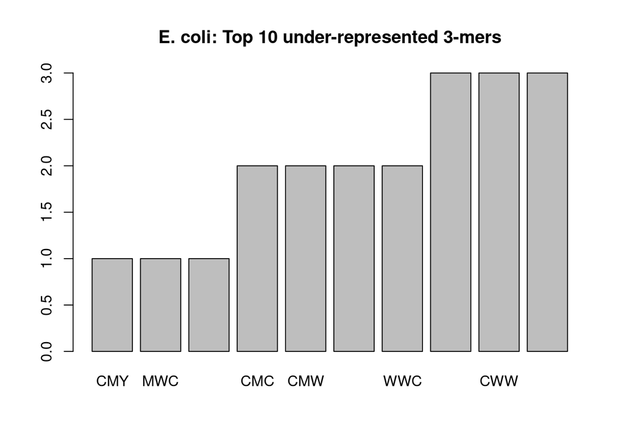

```r
barplot(as.numeric(top_under_E3),
        names.arg = names(top_under_E3),
        main = "E. coli: Top 10 under-represented 3-mers")
```

# The plots for over represented 3-mers in both the species shows high counts.E. coli favors 3-mers containing abundant amino acids like Leucine and Alanine (e.g., LLA, ALL, ALA), consistent with its overall amino acid usage. The most frequent 3-mer is LLA. S. aureus favors 3-mers containing amino acids (e.g., SDS, LLL, ILL). The most frequent 3-mer is SDS. Both organisms strongly favor sequences composed of highly abundant, structurally flexible amino acids, though the specific dominant motifs differ. # Both species show a similar pattern of avoiding sequences composed of rare amino acids (like Cysteine), but this avoidance is likely a consequence of the low overall genomic frequency of the component amino acids.

```r
#Translate CDS to protein sequence
prots_S <- lapply(cds_S, translate)
# E. coli
prots_ecoli <- lapply(cds_ecoli, translate)
```

```r
# Flatten proteins into a single vector
prots_S_vec <- unlist(prots_S)
prots_ecoli_vec <- unlist(prots_ecoli)
```

```r
aa <- unique(prots_S_vec)
aa <- aa[aa != "*"]  # Remove stop codons
```

```r
# Count 4-mers
k4_S <- count(prots_S_vec, wordsize = 4, alphabet = aa)
k4_ecoli <- count(prots_ecoli_vec, wordsize = 4, alphabet = aa)

# Top 10 over- and under-represented 4-mers
top_over_S4  <- head(sort(k4_S, decreasing = TRUE), 10)
top_under_S4 <- head(sort(k4_S, decreasing = FALSE), 10)

# Display results
print(top_over_S4)
```

```
##
## DSDS SDSD GKST LILL KEIE LLLL LKEI ALLI IALL LIIG
##  449  444   81   75   74   68   67   66   66   66
```

```r
print(top_under_S4)
```

```
##
## AACC AACK AACM AACP AACQ AACT AACW AADC AAFW AAGH
##    0    0    0    0    0    0    0    0    0    0
```

```r
# E. coli
top_over_E4  <- head(sort(k4_ecoli, decreasing = TRUE), 10)
top_under_E4 <- head(sort(k4_ecoli, decreasing = FALSE), 10)

# Print E. coli results
print(top_over_E4)
```

```
##
## LAAL ALAA LLAL LLLL AALA LLAA LLLA LALA LALL ALLA
##  234  233  215  209  207  206  197  196  195  193
```

```r
print(top_under_E4)
```

```
##
## ACAM ACCF ACCH ACCI ACCK ACCM ACCQ ACCW ACEW ACFP
##    0    0    0    0    0    0    0    0    0    0
```

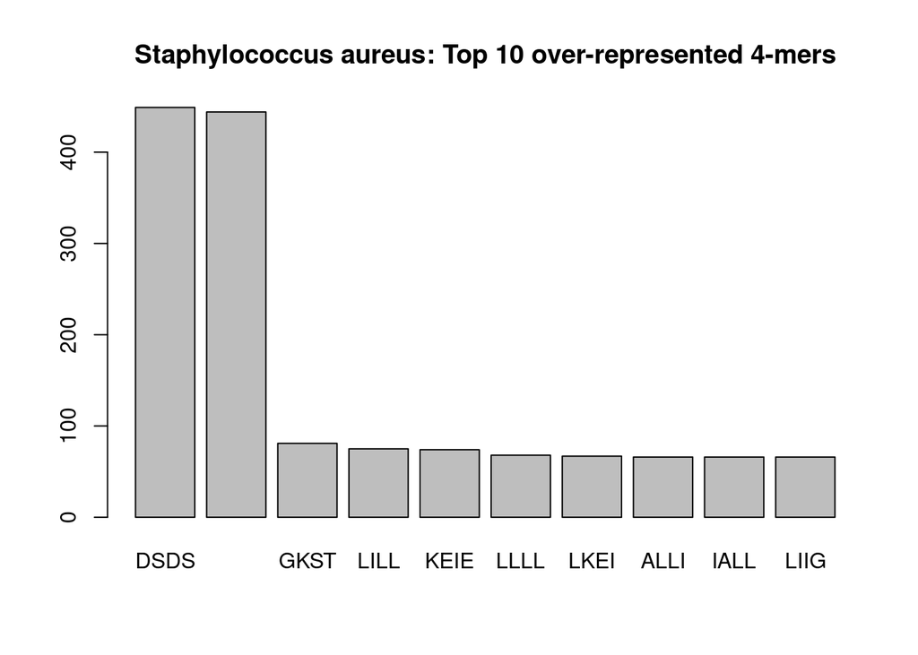

```r
# Plot top 10 over-represented 4-mers for Staphylococcus aureus
barplot(as.numeric(top_over_S4),
        names.arg = names(top_over_S4),
        main = "Staphylococcus aureus: Top 10 over-represented 4-mers")
```